# Getting Started with PSpower

## Overview

**PSpower** is a design-stage tool for planning observational and randomized studies that estimate treatment effects using propensity score (PS) weighting. It answers: *how large does my study need to be?*

Two functions cover the most common outcome types:

| Function | Outcome | Default test |
| --- | --- | --- |
| `power_ps()` | Continuous or binary | Two-sided |
| `power_cox()` | Time-to-event (survival) | One-sided |

> **This is a prospective planning tool.** Computing power after data are collected using the observed sample size (“post-hoc power”) is uninformative and should not be done.

### The sample size formula

For all outcome types, the required sample size takes the form

$$N = \left\lceil V \cdot
\frac{(z_{1-\alpha/k} + z_\beta)^2}{\delta^2} \right\rceil,$$

where $\delta$ is the standardized effect size, $\alpha$ is the significance level, $\beta$ is the target power, and $k = 2$ for a two-sided test or $k = 1$ for a one-sided test. All reported sample sizes are ceiling integers (rounded up to the nearest whole number).

The asymptotic variance $V$ is what distinguishes the two functions:

- **Continuous/binary** (`power_ps`): $V$ is the variance of the Hájek estimator, determined by $r$, $\phi$, $\rho^2$, and the estimand.
- **Survival** (`power_cox`): $V$ is the variance of the PS-weighted partial likelihood estimator, determined by $r$, $d_1$, $d_0$, $\tau_0 = \log(\text{HR})$, and (for observational studies) $\phi$ and the estimand.

### Inputs at a glance

**Common inputs**

*Effect size* — the standardized treatment effect $\delta = \tau / \text{SD}(Y)$ for continuous/binary outcomes, or the log hazard ratio $\tau_0 = \log(\text{HR})$ for survival outcomes. For continuous outcomes, $|\delta| = 0.2$ is considered small; 0.5 moderate; 0.8 large. For survival, $\text{HR} = 0.75$ gives $\tau_0 \approx -0.29$.

*Treatment proportion r* — the fraction of participants who receive treatment, $r = \Pr(Z = 1)$. A balanced design uses $r = 0.5$; in observational data, $r$ is estimated from the study population.

*Estimand* — the scientific quantity of interest:

- **ATE** — average treatment effect across the entire study population (inverse probability weights)
- **ATT** — average effect among the treated group (weights for group 1)
- **ATC** — average effect among the control group (weights for group 0); operationally equivalent to ATT with group labels swapped ($r \to 1 - r$, group 1 $\leftrightarrow$ group 0). Supported directly by `power_ps()`; for `power_cox()`, re-label groups and use `estimand = "ATT"`.
- **ATO** — average effect in the *overlap population* (overlap weights); the most efficient estimand when covariate overlap is limited

In a randomized trial all four estimands coincide.

**Continuous and binary outcomes** (`power_ps`)

*Overlap coefficient φ* — a number in $(0, 1)$ measuring how similar the PS distributions of the two groups are. $\phi = 1$ in a randomized trial; $\phi < 1$ reflects confounding, and sample size increases as $\phi$ decreases. Rule of thumb: $\phi \geq 0.95$ good; $[0.90, 0.95)$ moderate; $[0.85, 0.90)$ poor; $< 0.85$ very poor.

$\phi$ can be estimated from a pilot study or any dataset with fitted propensity scores using `overlap_coef()`. When it is not yet known, supplying a vector of plausible values (e.g., $\phi \in \{0.85, 0.90, 0.95\}$) allows $N$ to be computed across the plausible range.

*Confounder coefficient ρ²* — the squared correlation between the potential outcome $Y(0)$ and the PS linear predictor. When $\rho^2 = 0$ (the default), the outcome is unrelated to the confounders beyond the treatment indicator. A sensitivity analysis over $\rho^2 \in [0, 0.05]$ is recommended; values above 0.05 are uncommon in practice.

**Survival outcomes** (`power_cox`)

*Event rates d₁ and d₀* — the probability of observing an event during follow-up in the treated group ($d_1$) and the control group ($d_0$). These can be estimated from registries, pilot data, or published survival curves. If $d_0$ is omitted it is set equal to $d_1$.

*Study type* — `"rct"` for a randomized trial or `"obs"` for an observational study.

*Overlap coefficient φ* — required when `study_type = "obs"`; the same quantity as in `power_ps()`. See the rule of thumb and estimation guidance under the continuous/binary section above.

*Method* — `"robust"` (default) uses the sandwich variance, which accounts for the actual hazard ratio; `"schoenfeld"` is the classical formula derived under a null effect and may overestimate or underestimate the required $N$ relative to the robust method. Available only for randomized trials.

## 1. Continuous and binary outcomes: `power_ps()`

### Single scenario

Suppose we plan a study with:

- Standardized effect $\delta = 0.2$ (e.g., a 5-point difference in a symptom score with SD = 25)
- 50% of participants receive treatment ($r = 0.5$)
- Estimated overlap $\phi = 0.90$ (moderate)
- Target: 80% power, two-sided $\alpha = 0.05$

```r
res <- power_ps(
  effect_size = 0.2,
  r           = 0.5,
  phi         = 0.9,
  estimand    = "ATE",
  power       = 0.80
)
res
```

```
#> PSpower: power_ps
#> --------------------------------------------------
#> Estimand:                  ATE
#> Weights:                   inverse probability weights
#> Effect size:               0.200
#> Treatment proportion:      0.500
#> Overlap (phi):             0.900
#> Confounding (rho2):        0.000  [default]
#> --------------------------------------------------
#> Required sample size: 1058
#> Target power: 0.80  |  sig. level: 0.050  |  two-sided test
```

### Multiple configurations

Vectors can be supplied to any input; all combinations are computed automatically.

**Effect of treatment allocation**

The required sample size depends on how evenly participants are split between treatment and control. The following evaluates five values of $r$ across three estimands ($5 \times 3 = 15$ scenarios):

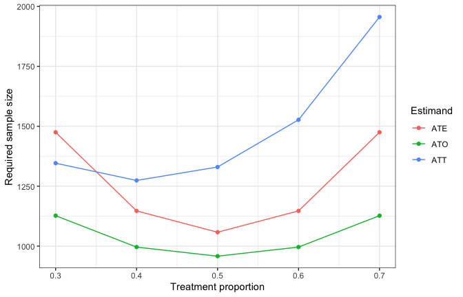

```r
res_r <- power_ps(
  effect_size = 0.2,
  r           = c(0.30, 0.40, 0.50, 0.60, 0.70),
  phi         = 0.90,
  estimand    = c("ATE", "ATT", "ATO"),
  power       = 0.80
)
plot(res_r)
```

**Effect of covariate overlap**

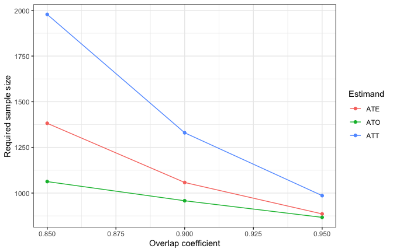

```r
res_phi <- power_ps(
  effect_size = 0.2,
  r           = 0.5,
  phi         = c(0.85, 0.90, 0.95),
  estimand    = c("ATE", "ATT", "ATO"),
  power       = 0.80
)
plot(res_phi)
```

```r
summary(res_phi)
```

```
#> PSpower: power_ps
#> -------------------------------------------------------
#> Scenarios: 9
#> Varying:  phi, estimand
#> Fixed:    effect_size = 0.2,  r = 0.5,  rho2 = 0 [default]
#> Target power: 0.80  |  sig. level: 0.050  |  two-sided test
#> -------------------------------------------------------
#>
#> Sample size (N, ceiling integer) distribution:
#>
#>           sample_size   phi           estimand
#>   Min:    867           0.95          ATO
#>   25%:    958           0.9           ATO
#>   50%:    1058          0.9           ATE
#>   75%:    1330          0.9           ATT
#>   Max:    1978          0.85          ATT
```

The ATO estimand consistently requires fewer participants than ATE, especially under poor overlap.

### Role of the confounder coefficient ρ²

The table below shows how $N$ changes across $\rho^2 \in [0, 0.05]$ for ATE with $\phi = 0.90$. A sensitivity analysis over this range is recommended; values above 0.05 are uncommon in practice.

```r
power_ps(
  effect_size = 0.2,
  r           = 0.5,
  phi         = 0.90,
  rho2        = c(0, 0.01, 0.02, 0.05),
  estimand    = "ATE",
  power       = 0.80
)
```

```
#> PSpower: power_ps
#> --------------------------------------------------
#> Scenarios: 4
#> Varying:  rho2
#> Fixed:    effect_size = 0.2,  r = 0.5,  phi = 0.9,  estimand = ATE
#> Target power: 0.80  |  sig. level: 0.050  |  two-sided test
#> --------------------------------------------------
#>  rho2 sample_size
#>  0.00        1058
#>  0.01        1065
#>  0.02        1072
#>  0.05        1093
```

An upper bound on $\rho^2$ can be obtained from the $R^2$ of a regression of the outcome on the study covariates using historical data.

## 2. Survival outcomes: `power_cox()`

### Randomized trial

#### Single scenario

```r
res_rct <- power_cox(
  effect_size = log(0.75),   # HR = 0.75
  r           = 0.5,
  d1          = 0.40,
  study_type  = "rct",
  power       = 0.80
)
res_rct
```

```
#> PSpower: power_cox
#> -------------------------------------------------------
#> Study type:                    Randomized trial
#> Method:                        Robust sandwich variance
#> Effect size (log hazard ratio): -0.288  [hazard ratio = 0.750]
#> Treatment proportion:          0.500
#> Event rate (group 1):          0.400
#> Event rate (group 0):          0.400  [= group 1]
#> -------------------------------------------------------
#> Required sample size: 795
#> Target power: 0.80  |  sig. level: 0.050  |  one-sided test
```

The default method uses the robust sandwich variance, which accounts for the actual hazard ratio. The Schoenfeld formula (derived under a null effect) does not correct for the effect size and may give a larger or smaller $N$:

```r
power_cox(
  effect_size = log(0.75),
  r           = 0.5,
  d1          = 0.40,
  study_type  = "rct",
  method      = "schoenfeld",
  power       = 0.80
)
```

```
#> PSpower: power_cox
#> -------------------------------------------------------
#> Study type:                    Randomized trial
#> Method:                        Schoenfeld formula
#> Effect size (log hazard ratio): -0.288  [hazard ratio = 0.750]
#> Treatment proportion:          0.500
#> Event rate (group 1):          0.400
#> Event rate (group 0):          0.400  [= group 1]
#> -------------------------------------------------------
#> Required sample size: 748
#> Target power: 0.80  |  sig. level: 0.050  |  one-sided test
```

#### Multiple configurations

The following evaluates three hazard ratios and three treatment proportions ($3 \times 3 = 9$ scenarios):

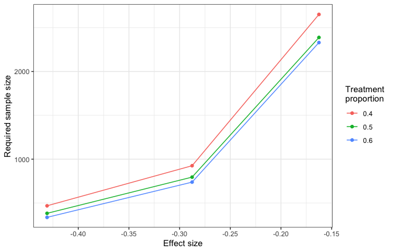

```r
res_rct_grid <- power_cox(
  effect_size = c(log(0.65), log(0.75), log(0.85)),
  r           = c(0.40, 0.50, 0.60),
  d1          = 0.40,
  study_type  = "rct",
  power       = 0.80
)
plot(res_rct_grid)
```

```r
summary(res_rct_grid)
```

```
#> PSpower: power_cox
#> ------------------------------------------------------------
#> Scenarios: 9
#> Varying:  effect_size, r
#> Fixed:    d1 = 0.4,  d0 = 0.4 [= group 1],  phi = NA,  study_type = rct,  estimand = ATE,  method = robust
#> Target power: 0.80  |  sig. level: 0.050  |  one-sided test
#> ------------------------------------------------------------
#>
#> Sample size (N, ceiling integer) distribution:
#>
#>           sample_size   effect_size   r
#>   Min:    336           -0.431        0.6
#>   25%:    468           -0.431        0.4
#>   50%:    795           -0.288        0.5
#>   75%:    2330          -0.163        0.6
#>   Max:    2651          -0.163        0.4
```

### Observational study

For observational studies, the overlap coefficient $\phi$ must also be provided. The ATE estimand uses inverse probability weights; ATO uses overlap weights and is more efficient when overlap is limited.

#### Single scenario

```r
res_obs <- power_cox(
  effect_size = log(0.75),
  r           = 0.5,
  d1          = 0.40,
  phi         = 0.90,
  study_type  = "obs",
  estimand    = "ATE",
  power       = 0.80
)
res_obs
```

```
#> PSpower: power_cox
#> -------------------------------------------------------
#> Study type:                    Observational study
#> Method:                        Robust sandwich variance
#> Estimand:                      ATE
#> Weights:                       inverse probability weights
#> Effect size (log hazard ratio): -0.288  [hazard ratio = 0.750]
#> Treatment proportion:          0.500
#> Event rate (group 1):          0.400
#> Event rate (group 0):          0.400  [= group 1]
#> Overlap (phi):                 0.900
#> -------------------------------------------------------
#> Required sample size: 1088
#> Target power: 0.80  |  sig. level: 0.050  |  one-sided test
```

#### Multiple configurations

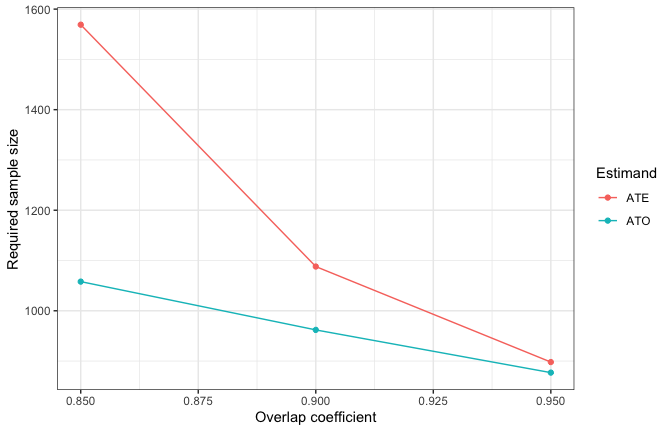

```r
res_obs_grid <- power_cox(
  effect_size = log(0.75),
  r           = 0.5,
  d1          = 0.40,
  phi         = c(0.85, 0.90, 0.95),
  study_type  = "obs",
  estimand    = c("ATE", "ATO"),
  power       = 0.80,
  n_mc        = 5e4    # use the default 1e6 in practice
)
plot(res_obs_grid)
```

```r
summary(res_obs_grid)
```

```
#> PSpower: power_cox
#> ------------------------------------------------------------
#> Scenarios: 6
#> Varying:  phi, estimand
#> Fixed:    effect_size = -0.288,  r = 0.5,  d1 = 0.4,  d0 = 0.4 [= group 1],  study_type = obs,  method = robust
#> Target power: 0.80  |  sig. level: 0.050  |  one-sided test
#> ------------------------------------------------------------
#>
#> Sample size (N, ceiling integer) distribution:
#>
#>           sample_size   phi           estimand
#>   Min:    877           0.95          ATO
#>   25%:    898           0.95          ATE
#>   50%:    1058          0.85          ATO
#>   75%:    1088          0.9           ATE
#>   Max:    1569          0.85          ATE
```

## 3. Estimating propensity score overlap from data

If a pilot dataset or a similar published cohort is available, $\phi$ can be estimated directly from fitted propensity scores using `overlap_coef()`.

```r
set.seed(2026)
n  <- 500
X  <- rnorm(n)
ps <- plogis(0.5 * X)   # fitted propensity scores from a PS model
Z  <- rbinom(n, 1, ps)

overlap_coef(ps = ps, Z = Z)
```

```
#> $phi
#> [1] 0.9696848
#>
#> $r
#> [1] 0.49
```

When no data are available, use the rule of thumb above and compute $N$ across the plausible range (e.g., $\phi \in \{0.85, 0.90, 0.95\}$), as shown in the examples above.

`overlap_coef()` also accepts Beta distribution parameters directly, which is useful when the PS distribution has been summarized in a published paper:

```r
overlap_coef(a = 3, b = 2)   # r = a/(a+b) = 0.60
```

```
#> $phi
#> [1] 0.9017928
#>
#> $r
#> [1] 0.6
```